# Trp53cor1 KO vs WT (Leg)

This file shows the wt-v-ko comparison for Trp53cor1.

Cuff overview:

```
## CuffSet instance with:
##   2 samples
##   26754 genes
##   77524 isoforms
##   0 TSS
##   23066 CDS
##   0 promoters
##   0 splicing
##   19954 relCDS
```

# QC

## Dispersion

Dispersion plot for genes in cuff: (Overdispersion can lead to innacurate quants)

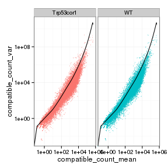

## Cross-replicate variability (fpkmSCVplot)

Differences in CV 2 can result in lower numbers of differentially expressed genes due to a higher degree of variability between replicate fpkm estimates.

Genes:

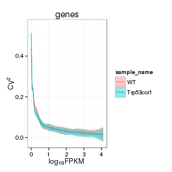

Isoforms:

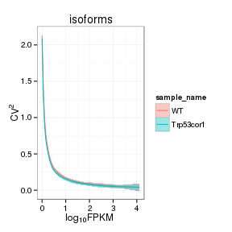

## MvA plot

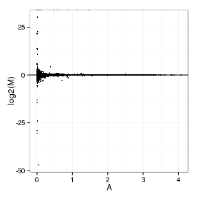

### MvA plot counts

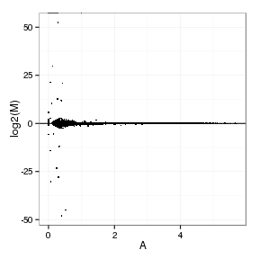

## Scatterplot matrix

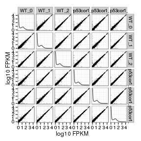

## Distributions

### Boxplots

Boxplot (genes)

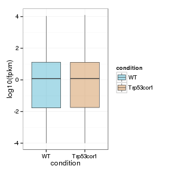

Boxplot (genes, replicates)

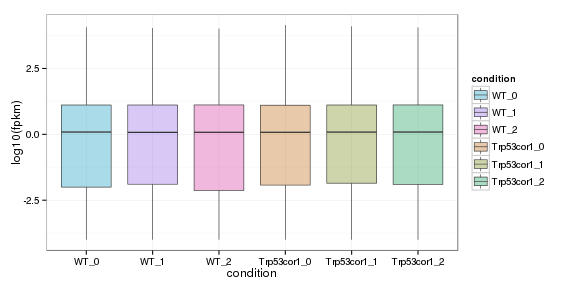

Boxplot (isoforms)

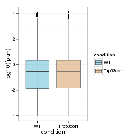

Boxplot (isoforms, replicates)

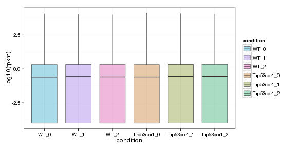

### Density

Density (genes)

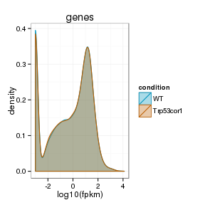

Density (genes, replicates)

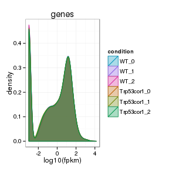

## Clustering

### Replicate Clusters

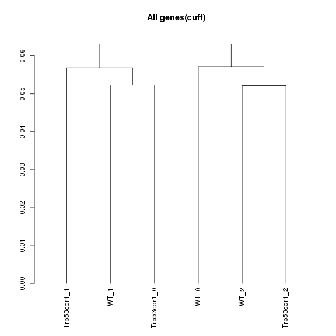

### PCA (genes)

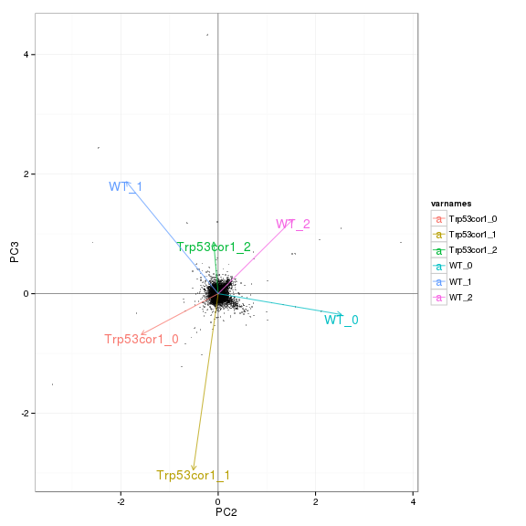

### MDS (genes)

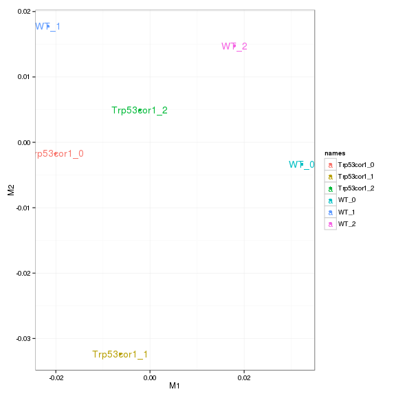

# KO assessment

## Endogenous lncRNA expression

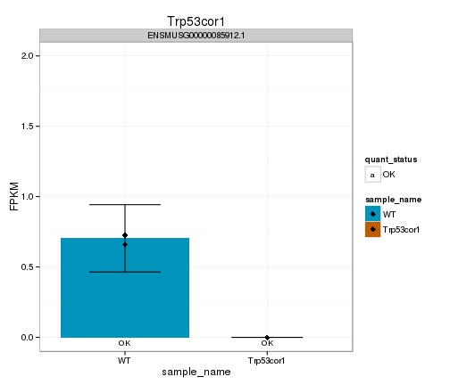

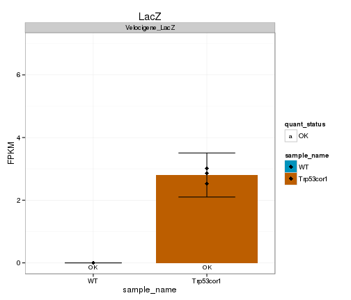

## Digital Genotyping (LacZ vs Endogenous lncRNA and Sex)

Eif2s3y is a y-expressed gene, Xist is an x-expressed gene Expression plot (endogenous linc, lacZ, Y-expressed gene):

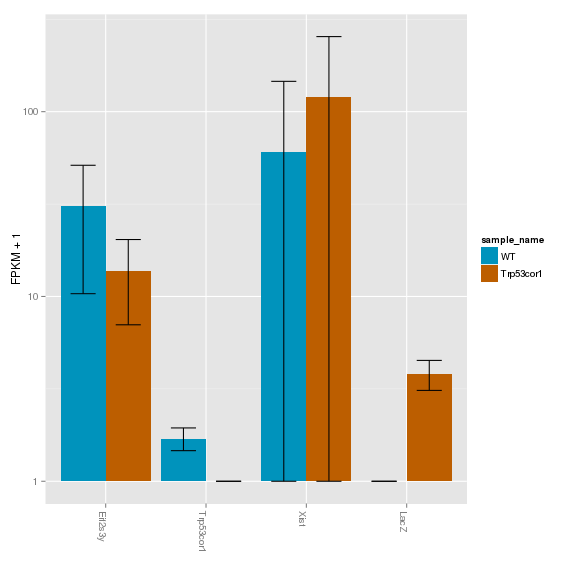

Expression heatmap:

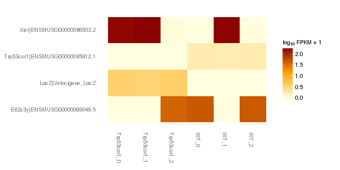

### Track visualization

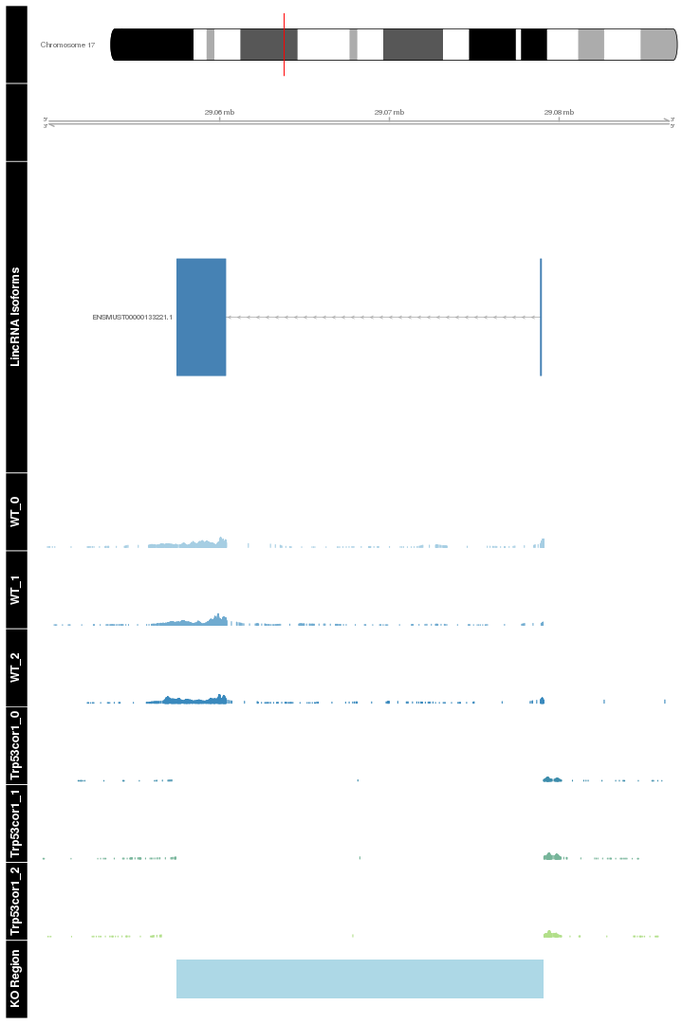

# Differential Analysis

## Differential Genes

There are 78 significantly differentially expressed genes. They are:

|  | geneAnnot$gene_short_name |
| --- | --- |
| 1 | Zfp40 |
| 2 | Myod1 |
| 3 | Myl2 |
| 4 | Atp1b4 |
| 5 | Matn4 |
| 6 | Mypn |
| 7 | Myh3 |
| 8 | Ldb3 |
| 9 | Cdkn1a |
| 10 | Zscan10 |
| 11 | Pi16 |
| 12 | Glo1 |
| 13 | Prss41 |
| 14 | Tpsab1 |
| 15 | Myot |
| 16 | Ankrd1 |
| 17 | Des |
| 18 | Tnnt2 |
| 19 | Tnni1 |
| 20 | Casq2 |
| 21 | Htra3 |
| 22 | Spp1 |
| 23 | Ibsp |
| 24 | Dmp1 |
| 25 | Lmod2 |
| 26 | Ckm |
| 27 | Csrp3 |
| 28 | Dbx1 |
| 29 | Ryr1 |
| 30 | Cox6a2 |
| 31 | Tnni2 |
| 32 | Tnmd |
| 33 | Myom2 |
| 34 | Hhatl |
| 35 | Ablim3 |
| 36 | Calm4 |
| 37 | Dnah8 |
| 38 | Rnps1 |
| 39 | Ssc5d |
| 40 | 3110052M02Rik |
| 41 | Arhgap36 |
| 42 | Hrc |
| 43 | Synpo2l |
| 44 | Myl6b |
| 45 | Rhod |
| 46 | Cilp |
| 47 | Mybph |
| 48 | Ptx4 |
| 49 | Nrap |
| 50 | Prss27 |
| 51 | Tagap1 |
| 52 | Hbb-y |
| 53 | Actn2 |
| 54 | Myh7 |
| 55 | Afp |
| 56 | Myh8 |
| 57 | Kdm5d |
| 58 | Zfp945 |
| 59 | Rps10-ps1 |
| 60 | Trim55 |
| 61 | Myl4 |
| 62 | Myl1 |
| 63 | Cytl1 |
| 64 | Krt77 |
| 65 | Ddx3y |
| 66 | 3425401B19Rik |
| 67 | 9030025P20Rik |
| 68 | Dnm3os |
| 69 | Hmga1-rs1 |
| 70 | Pisd-ps1 |
| 71 | Trp53cor1 |
| 72 | Susd5 |
| 73 | 1110002E22Rik |
| 74 | Rps2-ps10 |
| 75 | Gm20546 |
| 76 | Gm9825 |
| 77 | D930048G16Rik |
| 78 | LacZ |

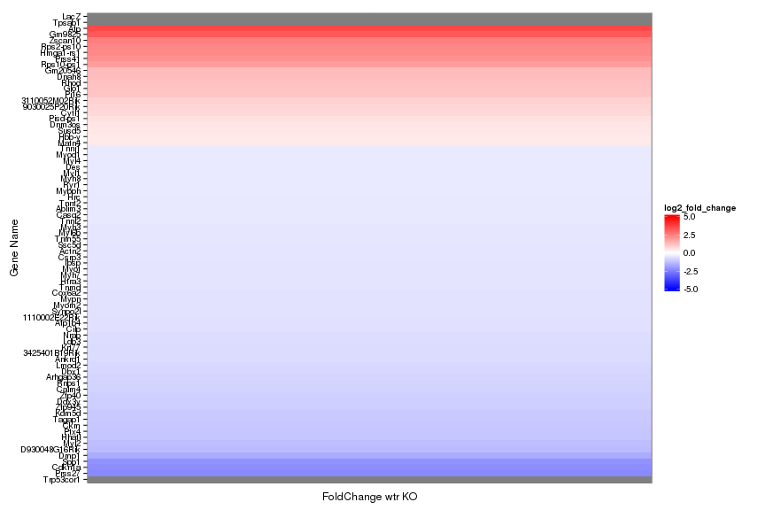

Expression heatmap of sigGenes

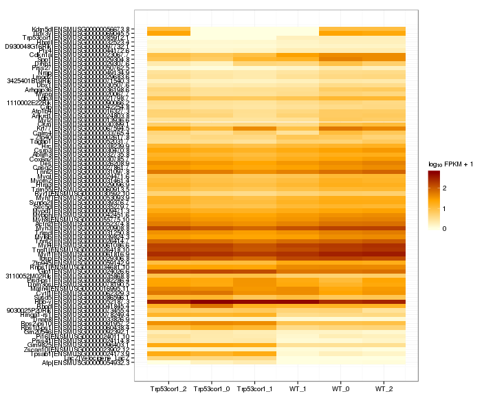

Foldchange heatmap of sigGenes

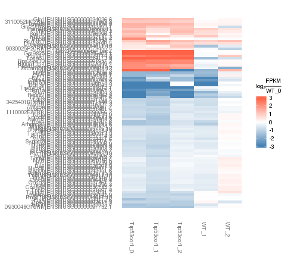

Now, look at genes that are detectably expressed (FPKM>0.5, yes I know it should be 1), and log2foldchange>2 in any direction: 25 genes

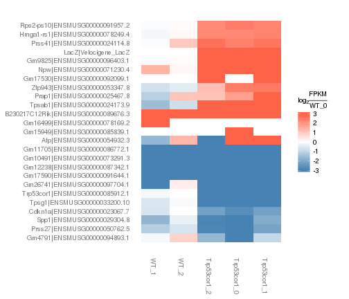

Now, those that are expressed, changing and called sig: 11 genes

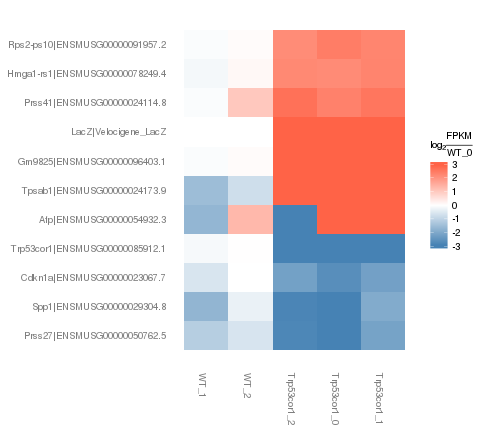

### Expression-level/significance relationship

Scatter plot of significant genes only:

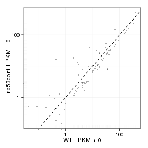

Volcano Plot

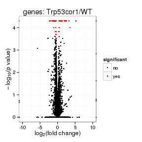

Volcano plot with significant genes only:

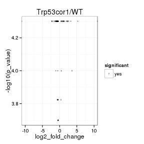

### Differential Isoforms between conditions

Per isoform difference between conditions:

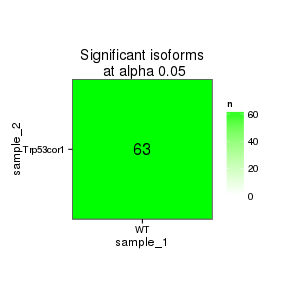

[output not shown]

[output not shown]

[output not shown]

[output not shown]